# Adaptive service real data - Exploratory Analysis

Main topic that will drive this analysis: *How can we evaluate and provide some quality feedback to try to enhance the knowledge graphs?*

## First step, try to get an idea of data quality

```r
with(tidyData,
    data.frame(num.of.students = length(unique(studentId)),
        num.of.knowledgeGraphs = length(unique(knowledgeGraph)),
        num.of.learningInstances = length(unique(learningInstance)),
        oldestEntry = min(tidyData$interactionEndTime, na.rm = TRUE),
        newsetEntry = max(tidyData$interactionEndTime, na.rm = TRUE)
    )
)
```

```
##   num.of.students num.of.knowledgeGraphs num.of.learningInstances
## 1           56362                     11                     5361
##   oldestEntry newsetEntry
## 1  1970-01-25  2015-01-30
```

Ok, so we have some dates in the 1970’s area… something to clean up later.

How much data withouth attemps or without timing info

```r
with(tidyData, mean(is.na(numberAttempts)))
```

```
## [1] 0.1220482
```

```r
mean(is.na(tidyData$timeOnItem))
```

```
## [1] 0.6063052
```

This sounds a lot! Let’s try to get an overview of this data to understand. Let’s plot an histogram of the distribution of the time passed on item. We overlay this histogram with a smooth density estimate. Finally, we add a red line to hilite the 600 seconds value.

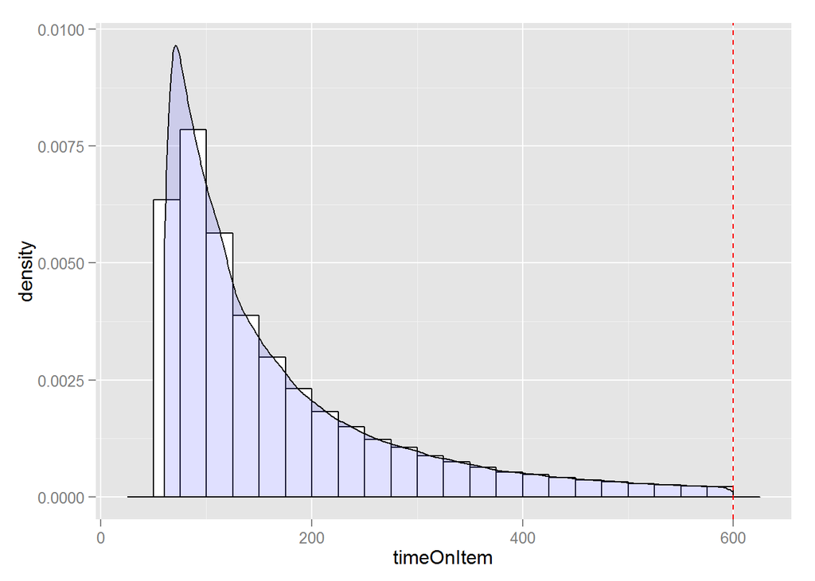

```r
# Histogram overlaid with kernel density curve
ggplot(tidyData, aes(x=timeOnItem)) +
    geom_histogram(aes(y=..density..),
                   binwidth=25,
                   colour="black", fill="white") +
    geom_density(alpha=.2, fill="#6666FF") +
    geom_vline(xintercept=600, size=0.4, color="red", linetype="dashed")
```

It looks like we’re facing a system constraint: after 600 seconds, a timeout is reached and no data is returned.

## Let’s try to get an idea of the time frame we’re working on

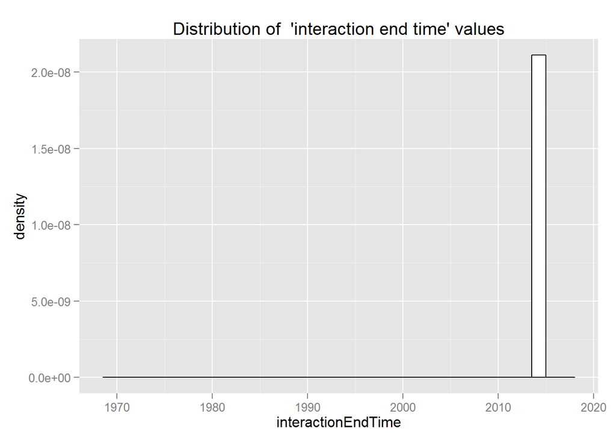

```r
ggplot(tidyData, aes(x=interactionEndTime), log10="y") +
    geom_histogram(aes(y=..density..),
                    colour="black", fill="white") +
    labs(title = "Distribution of  'interaction end time' values")
```

It looks like we have some outliers in the past that skew the data.

```r
summary(tidyData$interactionEndTime)
```

```
##                  Min.               1st Qu.                Median
## "1970-01-25 00:00:00" "2014-11-06 00:00:00" "2014-11-13 00:00:00"
##                  Mean               3rd Qu.                  Max.
## "2014-11-11 21:37:58" "2014-11-19 00:00:00" "2015-01-30 00:00:00"
##                  NA's
##              "207291"
```

This outlier looks like an isolated case according to the quartiles.

```r
date.outliers <- tidyData$interactionEndTime < as.POSIXct("2014-07-31", "%Y-%m-%d")

# Outliers overview
table(date.outliers)
```

```
## date.outliers
##   FALSE    TRUE
## 1490661     483
```

```r
# Outliers distribution overview
summary(tidyData$interactionEndTime[date.outliers == TRUE])
```

```
##                  Min.               1st Qu.                Median
## "1970-01-25 00:00:00" "2002-12-23 00:00:00" "2008-11-24 00:00:00"
##                  Mean               3rd Qu.                  Max.
## "2007-03-31 07:06:20" "2012-08-18 00:00:00" "2014-06-14 00:00:00"
##                  NA's
##              "207291"
```

```r
# Now we can fix these values
tidyData$interactionEndTime[date.outliers == TRUE] <- NA
```

#### How much recommendations served

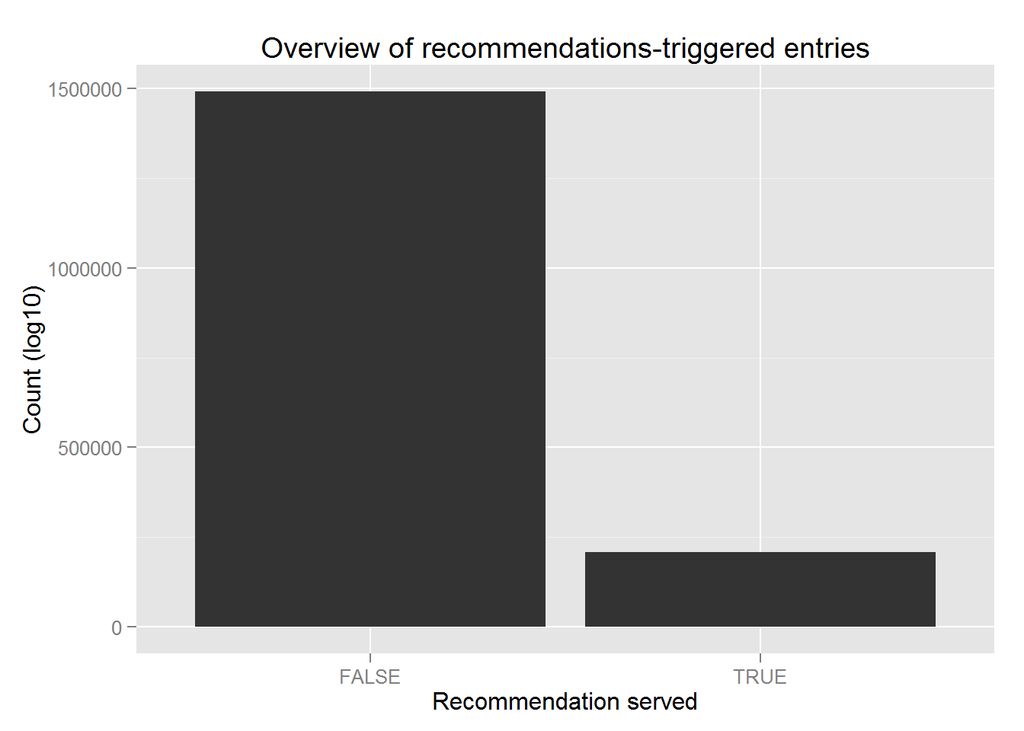

```r
ggplot(data=tidyData, aes(x=receivedRecommendation), log10="y")  +
    geom_bar(stat="bin") +
    labs(title = "Overview of recommendations-triggered entries",
         x = "Recommendation served",
         y = "Count (log10)")
```

#### Get an overview of how much adaptive contents has been served

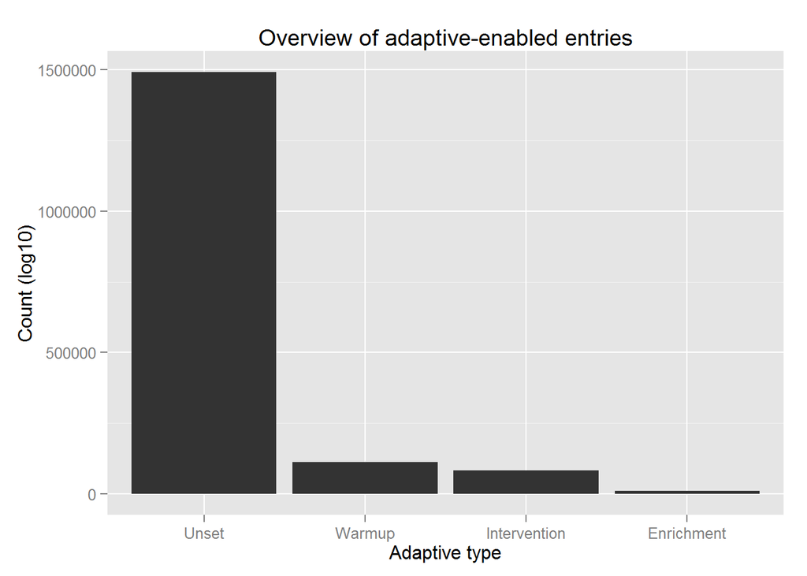

```r
ggplot(data=tidyData, aes(x=adaptiveType), log10="y")  +
    geom_bar(stat="bin")  +
    labs(title = "Overview of adaptive-enabled entries",
         x = "Adaptive type",
         y = "Count (log10)")
```

#### What kind of data we can anayse with theses Warmup/intervention/enrichment observations?

```r
# Get all the adaptive data
adaptive.data <- tidyData %>% filter( adaptiveType != "Unset" )
# Check what data is qualified for this subset
summary(adaptive.data$itemScore)
```

```
##    Min. 1st Qu.  Median    Mean 3rd Qu.    Max.    NA's
##      NA      NA      NA     NaN      NA      NA  207184
```

```r
summary(adaptive.data$interactionEndTime)
```

```
##     Min.  1st Qu.   Median     Mean  3rd Qu.     Max.     NA's
##       NA       NA       NA       NA       NA       NA "207184"
```

```r
summary(adaptive.data$numberAttempts)
```

```
##    Min. 1st Qu.  Median    Mean 3rd Qu.    Max.    NA's
##      NA      NA      NA     NaN      NA      NA  207184
```

```r
summary(adaptive.data$timeOnItem)
```

```
##    Min. 1st Qu.  Median    Mean 3rd Qu.    Max.    NA's
##      NA      NA      NA     NaN      NA      NA  207184
```

Well, ok…. so we won’t look into these observations against the recommendations.

Let’s look at the success ratio of each adaptive state versus non-adaptive one

```r
tidyData %>%
    group_by(adaptiveType) %>%
    summarise(success = mean(isCorrect))
```

```
## Source: local data frame [4 x 2]
##
##   adaptiveType   success
## 1        Unset 0.6632954
## 2       Warmup 0.4412535
## 3 Intervention 0.3575013
## 4   Enrichment 0.5616597
```

**Note for future analysis**: is it normal that the success rates are lower for adaptive-served items than for the non-adaptive ones?

#### Let’s try to get an idea of which knowledge graph to focus on

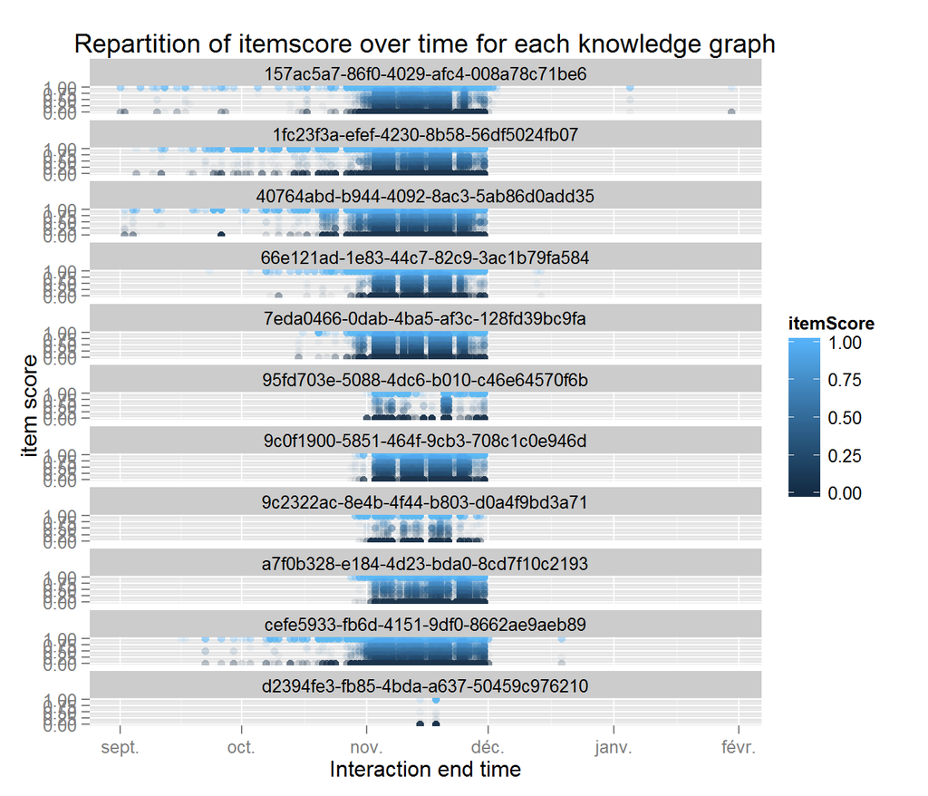

```r
ggplot(tidyData, aes(x=interactionEndTime, y=itemScore, color=itemScore)) +
    facet_wrap(~knowledgeGraph, ncol=1) +
    geom_point(alpha=0.05) +
    scale_color_gradient() +
    labs(title = "Repartition of itemscore over time for each knowledge graph",
         x = "Interaction end time",
         y = "item score")
```

We can see that most of the data is gathered around a few dates. For the next analysis we will focus our work on only this time span were most of the data is.

```r
analysis.data <- tidyData %>% filter(interactionEndTime < as.POSIXct("2014-11-28", "%Y-%m-%d"),
                                     interactionEndTime > as.POSIXct("2014-11-03", "%Y-%m-%d") )
```

#### Comparing the knowledge graphs

Now we will plot how the students performs in each of these knowledge graphs to see if the common behavior is always more or less the same or if some graphs stand out.

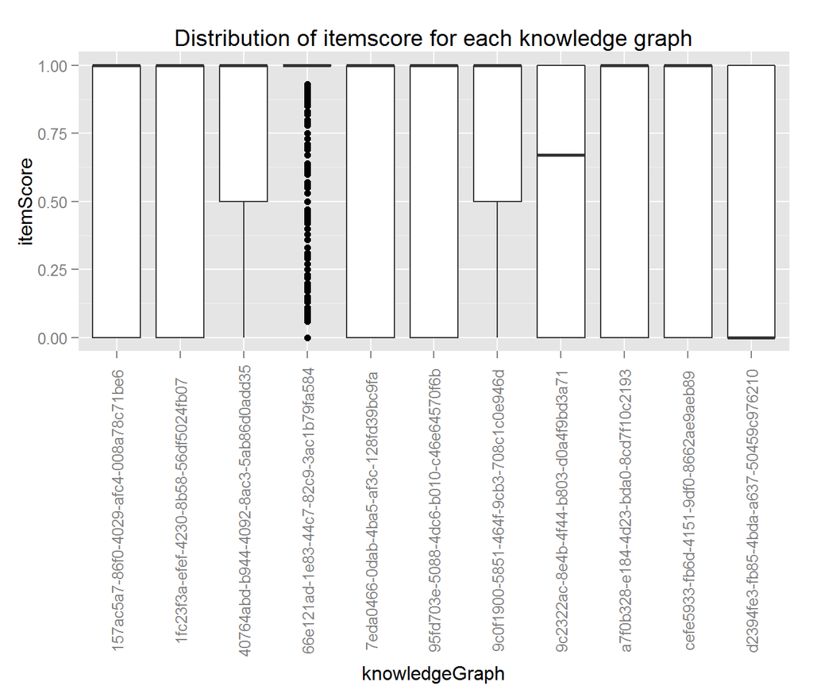

```r
ggplot(analysis.data , aes(x=knowledgeGraph, y=itemScore)) +
    geom_boxplot() +
    theme(axis.text.x  = element_text(angle=90, vjust=0.5)) +
    labs(title = "Distribution of itemscore for each knowledge graph")
```

Ok, The median seems to but most of the time in the roof. We can already see a few exceptions:

- knowledge graphs 40764a, 9c0f1 and 66e12 have few scores of 0. 66e12 looks like too easy, almost all data beeing 1. (**note for next steps**: investigate this graph!)
- on the other hand, the knowledge graph d2394f looks like too difficult, with a median near 0.

Let’s switch to a violin plot to try to get a better view of how the data is distributed.

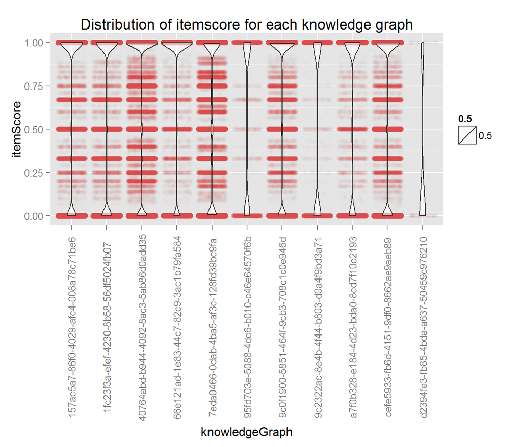

```r
ggplot(analysis.data , aes(x=knowledgeGraph, y=itemScore)) +
    geom_jitter(alpha=0.01, color="firebrick") +
    geom_violin(aes(alpha=.5)) +
    theme(axis.text.x  = element_text(angle=90, vjust=0.5)) +
    labs(title = "Distribution of itemscore for each knowledge graph")
```

Reminder: previously we’ve seen that the isCorrect ratio was better when adaptiveType was ‘unset’ than in any other adaptive step. From now, let’s try to analyse that in more details, and see if all the knowledge graphs are skewed in the same way.

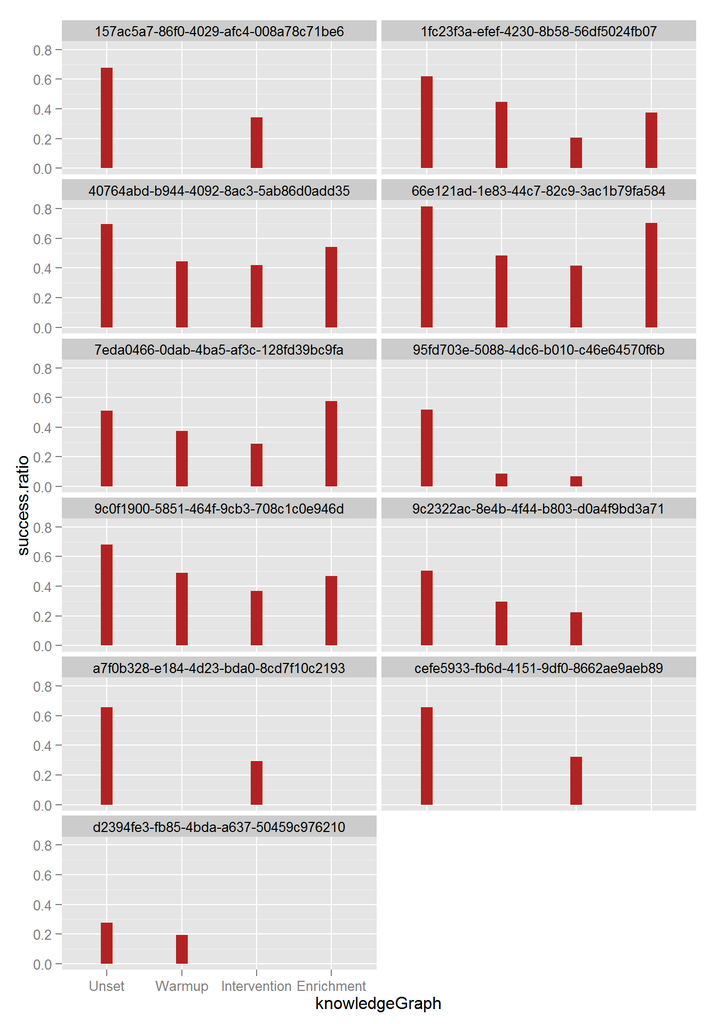

```r
# We group the data by knowledge graph and by adaptiveType
grp_cols <- c("knowledgeGraph", "adaptiveType")
dots <- lapply(grp_cols, as.symbol) # Convert character vector to list of symbols
# Then we compute the isCorrect rate for each combination
success.data <- tidyData %>%
    group_by_(.dots=dots) %>%
     summarise(success.ratio = mean(isCorrect)) %>% arrange(knowledgeGraph)


# Plot these ratio to have an overview of the trends
ggplot(success.data, aes(knowledgeGraph, success.ratio)) +
    geom_linerange(success.data,
                   mapping = aes(x=adaptiveType, ymin=0, ymax=success.ratio),
                   colour = "firebrick", alpha=1, size=4) +
    facet_wrap(~knowledgeGraph, ncol = 2)
```